# Risk Management

### MoSEF Paris I Panthéon Sorbonne 2019-2020

### Lecturer: Matthieu Garcin

#### Group: Leka Geri, Puchetti Lucas

```python
import pandas as pd
import numpy as np
from scipy.stats import norm, anderson
from scipy.stats import skewnorm, skewtest , gaussian_kde
import random
import hurst
import matplotlib.pyplot as plt
import seaborn

from tabulate import tabulate
from IPython.display import Latex

import statsmodels.api as sm
import random
```

```python
try:
    sp500 = pd.read_csv('^GSPC.csv')[['Date','Adj Close']]
except FileNotFoundError:
    sp500 = pd.read_csv('GSPC.csv')[['Date','Adj Close']]
sp500['Date'] = pd.to_datetime(sp500['Date'])
sp500.set_index('Date', inplace=True)
sp500 = sp500.pct_change().dropna()
#sp500.reset_index(inplace=True )
sp500.rename(columns={'Adj Close': 'Returns'}, inplace=True)
```

Thanks to the test below we can have a general idea about the distribution of our returns.

```python
result = anderson(sp500['Returns'])
p = 0
print('Checking if returns are normally disributed')
print('Statistic: %.3f' % result.statistic)
for i in range(len(result.critical_values)):
    sl, cv = result.significance_level[i], result.critical_values[i]
    if result.statistic < result.critical_values[i]:
        print('%.3f: %.3f, data looks normal (fail to reject H0)' % (sl, cv))
    else:
        print('%.3f: %.3f, data does not look normal (reject H0)' % (sl, cv))
```

```
Checking if returns are normally disributed
Statistic: 14.348
15.000: 0.573, data does not look normal (reject H0)
10.000: 0.653, data does not look normal (reject H0)
5.000: 0.783, data does not look normal (reject H0)
2.500: 0.913, data does not look normal (reject H0)
1.000: 1.086, data does not look normal (reject H0)
```

```python
print('Checking if returns are skew disributed')
print("Skewtest result p-value: "+str(skewtest(sp500['Returns'])[1]))
p = 0.05
if skewtest(sp500['Returns'])[1] < p:
    print('Data look Skew Distributed (moment of order 3)')
else:
    print('Data does not look Skew Distributed')
```

```
Checking if returns are skew disributed
Skewtest result p-value: 1.52707601606539e-10
Data look Skew Distributed (moment of order 3)
```

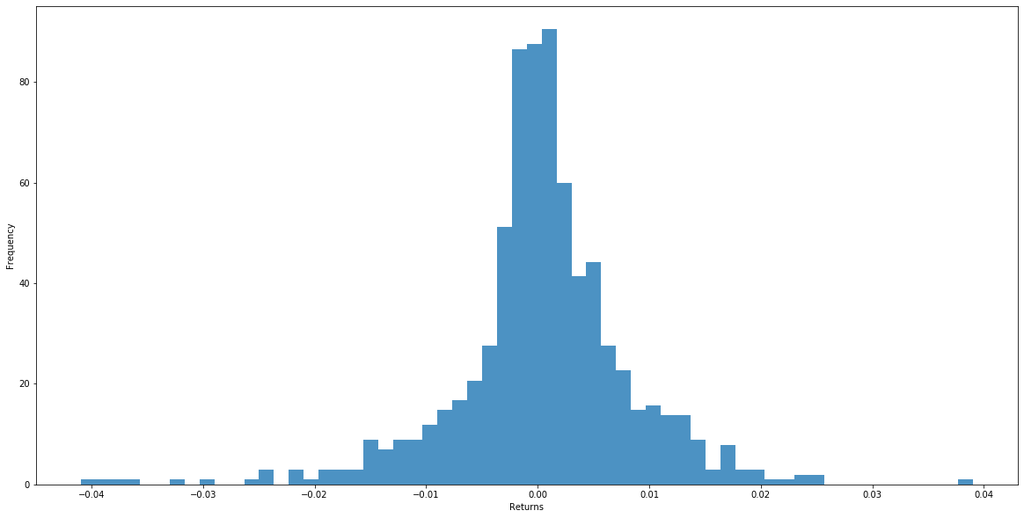

```python
plt.figure(figsize=(20,10))
plt.hist(sp500['Returns'],bins=60,alpha=0.8,density = True)
plt.xlabel('Returns')
plt.ylabel('Frequency')
plt.show()
```

#### Question 1. Determine your VaR at 99% at a one-day horizon using alternatively the following methods:

##### Empirical Quantile (historical simulation):

```
This method employs historical returns data to assemble the cumulative distribution function, and does not place any assumptions on the shape of the distribution.

A historical simulation simply sorts the returns by size.  If the sample include 100 returns, the value at risk at a confidence of 95% is the fifth largest loss.

Several criticisms are often made of this approach:

- Historical simulation assumes that returns are independent and identically distributed. This not necessarily the case, real-world data often displays volatility clustering.
- Returns in the recent-past and far-past are given equal weighting. However, recent returns have greater bearing on future behavior than older returns.
- This method requires a large set of historical data for accuracy; this, however, is not always available.
- Because the method is entirely reliant on historical data, the result cannot be influenced by subjective information (as with Monte-Carlo simulation). This may be significant if a fund manager predicts large changes in the business environment.
```

```python
# Short method is the usage of np.percentile(df,1)
sortedSP500 = sp500.sort_values('Returns',ascending=True)
VaR_99_Hist = sortedSP500['Returns'].quantile(0.01 , interpolation="nearest")
print(tabulate([['99%',str(round(100*VaR_99_Hist, 3))+"%"]],
               headers = ['Confidence Level', 'Parametric VaR'],
               colalign=("left","right")))
```

```
Confidence Level      Parametric VaR
------------------  ----------------
99%                          -2.452%
```

##### Parametric Distribution (Variance-Covariance Method):

```
This approach for calculating the value at risk is also known as the delta-normal method. It needs the average returns, variances and correlation coefficients (derived from historical data). The variance-covariance method assumes that historical returns are normally distributed, and that the future will mirror the past.

The calculation is straightforward, and for a one-asset portfolio is given by this equation, where xα is the αth percentile of a normal distribution, and P is the asset value.
```

\begin{align} \ VaR_{1-\alpha}=-x_{\alpha }P \end{align}

```python
spMean = np.mean(sp500['Returns'])
std_dev = np.std(sp500['Returns'])
confidence_level = 0.01
VaR_99_Para = norm.ppf(confidence_level, spMean, std_dev)
print(tabulate([['99%',str(round(100*VaR_99_Para, 3))+"%"]],
               headers = ['Confidence Level', 'Parametric VaR'],
               colalign=("left","right")))
```

```
Confidence Level      Parametric VaR
------------------  ----------------
99%                           -1.83%
```

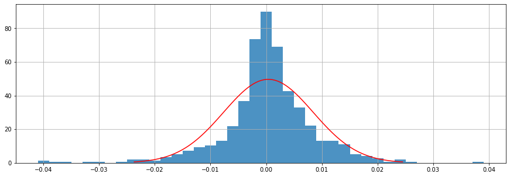

```python
plt.figure(figsize=(15,5))
sp500['Returns'].hist(bins=40, density=True, alpha=0.8)
x = np.linspace(spMean - 3*std_dev, spMean + 3*std_dev, 100)
plt.plot(x,norm.pdf(x, spMean, std_dev), "r" )
plt.show()
```

##### Nonparametric Distribution (Monte Carlo Method):

```
The Monte-Carlo Method involves running multiple trials to calculate the portfolio returns.  Generally, this method involves the following steps.
  - Generate simulated returns by sampling a probability distribution.
  - Order the returns by size
  - Compute the VaR at the required confidence level. For a simulation of 1000 returns, the 95% percentile would correspond to the 50th lowest value.

Monte-Carlo simulation is an extremely flexible method for calculating Value at Risk. This is because any probability distribution can be selected for all the significant risk factors. However, for a large investment universe, Monte-Carlo simulation can be computationally intensive.
```

```python
# Aggregate the returns
sim_returns = []
# Loop through 100 simulations
for i in range(10000):
    # Generate the Random Walk
    rand_rets = np.random.normal(spMean, std_dev)
    # Save the results
    sim_returns.append(rand_rets)
# Calculate the VaR(99)
confidence_level = 0.01
VaR_99_Npara = np.percentile(sim_returns, confidence_level)
print(tabulate([['99%',str(round(100*VaR_99_Npara, 3))+"%"]],
               headers = ['Confidence Level', 'Non-parametric VaR'],
               colalign=("left","right")))
```

```
Confidence Level      Non-parametric VaR
------------------  --------------------
99%                              -2.855%
```

The Non-Parametric VaR is greater than the others, but we find it a little bit odd that the Parametric VaR is only that much. This is due to the fact that we assume that our data are normally distributed (hence the test that we did at the beginning by stating that our data doesn't follow a normal distribution).

```python
print('VaR 99% Empirical Quantile: ', str(round(100*VaR_99_Hist, 3))+"%")
print('VaR 99% Parametric Distribution: ', str(round(100*VaR_99_Para, 3))+"%")
print('VaR 99% Non-Parametric Distribution: ', str(round(100*VaR_99_Npara, 3))+"%")
```

```
VaR 99% Empirical Quantile:  -2.452%
VaR 99% Parametric Distribution:  -1.83%
VaR 99% Non-Parametric Distribution:  -2.855%
```

#### Question 2 : Using the estimator of Pickands, determine the parameter of the GEV function of losses and comment its value.

\begin{align} \ \textrm{ Pickand's Estimator : }\xi_{k,n}^{Pick} = \frac{1}{ln2}ln\left(\frac{X_{n-k+1,n} - X_{n-2k+1,n}}{X_{n-2k+1,n} - X_{n-4k+1,n}}\right),\textrm{ for } k = 1,...,\lfloor\frac{n}{4}\rfloor \end{align}

With n being the lenght of our series and k, chosen by us.

```python
def pickandsEstimator(xArray , k=5):
    # Estimates the xi parameter of a GEV distribution.
    # Inputs: xArray: an array of values.
    #         k : a parameter. Must be integer.
    # Returns: The shape parameter estimation.
    xArray = -np.array(xArray)
    xArray.sort()
    n = xArray.shape[0]-1 # for calculation we need len - 1, not len
    return (1/np.log(2))*np.log((xArray[n-k+1]- xArray[n-2*k+1])
                               /(xArray[n-2*k+1]- xArray[n-4*k+1]))

# We switch sign on the returns because we are
# interested in maximal loss, not maximal gain.
sp500Q2 = np.array(sp500.Returns.copy())
k = 5
length = sp500Q2.shape[0]-1
pickPara = pickandsEstimator(sp500Q2 , k)

print('Parametre n: '+str(length+1),
      '\nParametre k: '+str(k),
      '\nParametre of Pickand : '+str(pickPara))
```

```
Parametre n: 762
Parametre k: 5
Parametre of Pickand : 0.4653896807591753
```

*Since our value is positive, we end up with a Fréchet or type II extreme value distribution because:*

\begin{align} \ \xi = \alpha^{-1}>0 \end{align}

*Showing how much the parameter of Pickand will change if k changes. Here we will have a better understanding.*

- If k tends to infinity we see that the Pickand estimator goes negative.

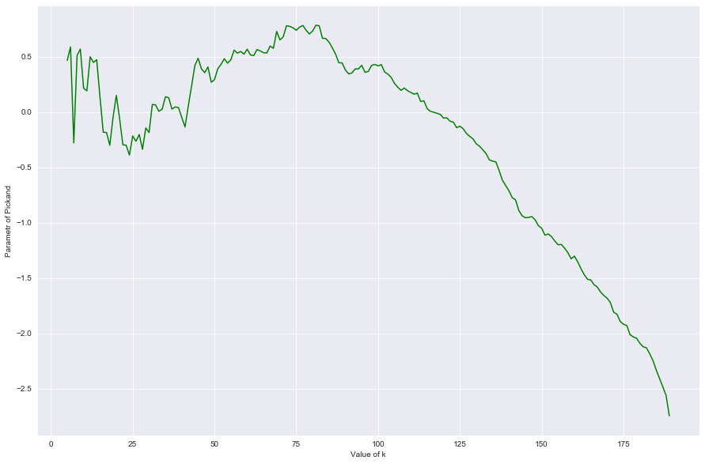

```python
pcikValues = []
kvalues =[]
for k in range(5,int(length//4)):
    pickPar = pickandsEstimator(sp500Q2 , k)
    pcikValues.append(pickPar)
    kvalues.append(k)

seaborn.set_style("darkgrid")
plt.figure(figsize=(15,10))
plt.plot(kvalues,pcikValues,c='green')
plt.xlabel('Value of k')
plt.ylabel('Parametr of Pickand')
plt.show()
```

The VaR using the Pickand estimator:

\begin{align} \ VaR(p) = \frac{(\frac{k}{n(1-p)})^{\xi^{P}}-1}{1-2^{-\xi^{P}}}(X_{n-k+1:n} - X_{n-2k+1:n}) + X_{n-k+1:n} \end{align}

where the Pickand estimateur is the GEV one.

#### Question 3. Determine the VaR at 99% at a one-day horizon using the EVT approach.

```python
def pickandsVAR(p , xi , k , xArray):
    xArray = -np.array(xArray)
    xArray.sort()
    n = xArray.shape[0]-1 # for calculation we need len - 1, not len
    var = ((np.power(k/(n*(1-p)) , xi) - 1)/(1 - np.power(2 , -xi))) * (xArray[n-k+1] - xArray[n-2*k+1]) + xArray[n-k+1]
    return -var
```

```python
xi = pickPara
k = 5
p = 0.99
n = length
sp500Q2 =  sp500.Returns.copy()
VaRpickand = pickandsVAR(p , xi , k , sp500Q2)
print(tabulate([['99%',str(round(100*VaRpickand, 3))+"%"]],
               headers = ['Confidence Level', 'VaR Pickand GEV:'],
               colalign=("left","right")))
```

```
Confidence Level      VaR Pickand GEV:
------------------  ------------------
99%                             -2.66%
```

#### Question 4. What is Leadbetter's extremal index for the dataset? Comment its value and explain how you should change your VaR to take this into account (only provide an explanation, with equations, do not calculate a new VaR).

The extremal index is an important parameter measuring the degree of clustering of extremes in a stationary process. If we consider the point process of exceedance time over a high threshold, this can be shown to converge asymptotically to a clustered Poisson process. The extremal index, a parameter in the interval [0,1], is the reciprocal of the mean cluster size. Apart from being of interest in its own right, it is a crucial parameter for determining the limiting distribution of extreme values from the process.

**Unfortunately, I couldn't find the formula so I asked for help for this question**

```python
def Leadbetter(data,b,degré_seuil):
    n=len(data)
    k = int(n/b)
    seuil = np.log(degré_seuil)/100
    value = data.Returns.values
    somme_value = sum((value < seuil)) #on prend inférieur car on s'intéresse à nos pertes (inférieur négativement)
    somme = []
    for i in np.arange(1,k+1):
        a= (i-1)*b
        z= i * b
        n= value[a-1:z]
        if len(n) != 0:
            somme.append(max(value[a-1:z]) > seuil)
    Leadbetter_index = 1/(sum(somme)/somme_value)
    return print("The value of the extremal index Leadbetter: {} ".format(str(round(Leadbetter_index,3))))
Leadbetter(sp500,10,0.05)
```

```
The value of the extremal index Leadbetter: 0.067
```

#### Question 5. What is a Hurst exponent and how can one interpret its value?

The Hurst exponent is used as a measure of long-term memory of time series. It relates to the autocorrelations of the time series, and the rate at which these decrease as the lag between pairs of values increases.

The Hurst exponent is referred to as the "index of dependence" or "index of long-range dependence". It quantifies the relative tendency of a time series either to regress strongly to the mean or to cluster in a direction. A value H in the range 0.5–1 indicates a time series with long-term positive autocorrelation, meaning both that a high value in the series will probably be followed by another high value and that the values a long time into the future will also tend to be high. A value in the range 0 – 0.5 indicates a time series with long-term switching between high and low values in adjacent pairs, meaning that a single high value will probably be followed by a low value and that the value after that will tend to be high, with this tendency to switch between high and low values lasting a long time into the future. A value of H=0.5 can indicate a completely uncorrelated series, but in fact it is the value applicable to series for which the autocorrelations at small time lags can be positive or negative but where the absolute values of the autocorrelations decay exponentially quickly to zero. This in contrast to the typically power law decay for the 0.5 < H < 1 and 0 < H < 0.5 cases.

The Hurst exponent, H, is defined in terms of the asymptotic behaviour of the rescaled range as a function of the time span of a time series as follows:

$$ {\displaystyle \mathbb {E} \left[{\frac {R(n)}{S(n)}}\right]=Cn^{H}{\text{ as }}n\to \infty \,,} $$

where;

- $R(n)$ is the range of the first n cumulative deviations from the mean, and $S(n)$ is their standard deviation
- ${\displaystyle \mathbb {E} \left[x\right]\,}$ is the expected value
- $n$ is the time span of the observation (number of data points in a time series)
- $C$ is a constant.

#### Question 6. Propose a risk measure taking into account the Hurst exponent and calculate its value for the price series used in this project. The Hurst exponent must be estimated with the absolute-moment estimator. This risk measure must take into account the autocovariance of a fBm (like in the Nuzman-Poor approach for predictions).

First, we estimate the Hurst exponent.

```python
def hurstEstimator(xDF):
    X = xDF.sort_index().values
    N = X.shape[0] - 1

    def empiricalAbsoluteMoment(X , N , k=1):
        return np.sum(np.power(X[1*k::k] - X[:-1*k:k] , 2))
    factor = 1/(2*np.log(2))

    return factor * np.log( 0.5 * ( empiricalAbsoluteMoment(X , N , 1 ) / \
                                    empiricalAbsoluteMoment(X , N , 2 )   ))
Hhat = hurstEstimator(sp500)

print('The Hurst exponent is :'+str(Hhat))
```

```
The Hurst exponent is :0.03914273473231314
```

Then we take use the return series to get several 100-rolling-days series by month

```python
rollingHhat = [ hurstEstimator(sp500.iloc[i : i+100].copy() ) for i in range(0 , 663 , 20)  ]
print("\n".join(map(lambda y : str(round(y , 4)) , rollingHhat[:5])))
```

```
0.0249
-0.2061
-0.0785
0.0115
-0.0441
```

The prescence of negative values makes us think our estimation of the Hurst exponent is incorrect. In order to propose a risk measurement, we will use the `hurst` library to estimate H by the rescaled range estimation.

```python
Hhat = hurst.compute_Hc(sp500 , simplified=False)
Hhat[0]
```

```
0.29330323157807814
```

Now, again we take use the return series to get several 100-rolling-days series by month.

```python
rollingHhat = [ hurst.compute_Hc(sp500.iloc[i : i+100].copy() , simplified=False)[0] for i in range(0 , 663 , 20)  ]
rollingHhat = np.array(  rollingHhat )
```

We resample from the non-parametric distribution of $\hat{H}$:

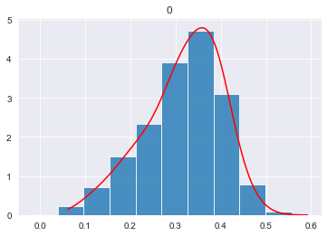

```python
distH = gaussian_kde(rollingHhat)
rand_hurst = np.array(distH.resample(size=10000 ))
x = pd.DataFrame(rand_hurst.T)
plt.figure(figsize=(15,5))
x.hist( density=True, alpha=0.8)
axis = np.linspace(x.median() - 3*x.std(), x.median() + 3*x.std(), 100)
hurstAxis = [distH(i) for i in axis]
plt.plot(axis,hurstAxis, "r" )
plt.show()
```

We look at the distribution of the Hurst exponent to see the likelihood of the series to be mean reversive. We can see below that our returns are very likely to be mean reversive.

#### Question 7. For each of the methods exposed above for calculating VaR, expose a method to extend them to ES. Calculate the 99% ES on the same sample.

Conditional Value at Risk (CVaR), also known as the expected shortfall, is a risk assessment measure that quantifies the amount of tail risk an investment portfolio has. CVaR is derived by taking a weighted average of the “extreme” losses in the tail of the distribution of possible returns, beyond the value at risk (VaR) cutoff point. It can also be calculated using the integral from -1 to VaR with the following formula:

$$ CVaR = \frac{1}{1-c}\int_{VaR}^{-1}xp(x)dx$$

```python
print('VaR 99% Empirical Quantile: ', str(round(100*VaR_99_Hist, 3))+"%")
print('VaR 99% Parametric Distribution: ', str(round(100*VaR_99_Para, 3))+"%")
print('VaR 99% Non-Parametric Distribution: ', str(round(100*VaR_99_Npara, 3))+"%")
print('VaR 99% Pickand GEV: ', str(round(100*VaRpickand, 3))+"%")
```

```
VaR 99% Empirical Quantile:  -2.452%
VaR 99% Parametric Distribution:  -1.83%
VaR 99% Non-Parametric Distribution:  -2.855%
VaR 99% Pickand GEV:  -2.66%
```

```python
CVaR_95_Hist = sp500[sp500 <= VaR_99_Hist].mean()
CVaR_95_Para = sp500[sp500 <= VaR_99_Para].mean()
CVaR_95_Npara = sp500[sp500 <= VaR_99_Npara].mean()
CVaR_95_Pick = sp500[sp500 <= VaRpickand].mean()
```

*We have a tie between Non-Parametric VaR and Pickand. As always the Parametric one is lower than the other.*

```python
print('CVaR 99% Empirical Quantile: ', str(round(100*CVaR_95_Hist[0], 3))+"%")
print('CVaR 99% Parametric Distribution: ', str(round(100*CVaR_95_Para[0], 3))+"%")
print('CVaR 99% Non-Parametric Distribution: ', str(round(100*CVaR_95_Npara[0], 3))+"%")
print('CVaR 99% Pickand GEV: ', str(round(100*CVaR_95_Pick[0], 3))+"%")
```

```
CVaR 99% Empirical Quantile:  -3.227%
CVaR 99% Parametric Distribution:  -2.68%
CVaR 99% Non-Parametric Distribution:  -3.588%
CVaR 99% Pickand GEV:  -3.588%
```

#### Question 8. Backtest the ESs and the corresponding VaRs on your sample. Pay attention to the strict separation of estimation sample and test sample for this question (for the other questions, simply estimate the risk measures on the whole sample). Comment the result about the relative accuracy of ES and VaR.

```python
X = sp500['Returns'].values
train_size = int(len(X) * 0.7)
train, test = X[0:train_size], X[train_size:len(X)]
train=list(train)
test=list(test)
```

```python
spMean_train = np.mean(train)
std_dev_train = np.std(train)
confidence_level = 0.01

# Historic VaR
VaR_99_Hist_test = np.percentile(train, confidence_level)
# Parametric VaR
VaR_99_Para_test = norm.ppf(confidence_level, spMean_train, std_dev_train)
# NonParametric VaR
sim_returns = []
for i in range(1000):
    rand_rets = np.random.normal(spMean_train, std_dev_train, 1000)
    sim_returns.append(rand_rets)
VaR_99_Npara_test = np.percentile(sim_returns, confidence_level)

# VaR Pickand GEV
k = 5
length = len(test)-1
test.sort()
pickPar_test = pickandsEstimator(test , k)

xi = pickPar_test
p = 0.99
n = length

VaRpickand_test = pickandsVAR(p , xi , k , test)

print('VaR 99% Empirical Quantile: ', str(round(100*VaR_99_Hist_test, 3))+"%")
print('VaR 99% Parametric Distribution: ', str(round(100*VaR_99_Para_test, 3))+"%")
print('VaR 99% Non-Parametric Distribution: ', str(round(100*VaR_99_Npara_test, 3))+"%")
print('VaR 99% Pickand GEV: ', str(round(100*VaRpickand_test, 3))+"%")
```

```
VaR 99% Empirical Quantile:  -3.923%
VaR 99% Parametric Distribution:  -1.968%
VaR 99% Non-Parametric Distribution:  -3.159%
VaR 99% Pickand GEV:  -1.971%
```

```python
test_array= np.array(test)
CVaR_95_Hist_test = test_array[test_array <= VaR_99_Hist_test].mean()
CVaR_95_Para_test = test_array[test_array <= VaR_99_Para_test].mean()
CVaR_95_Npara_test = test_array[test_array <= VaR_99_Npara_test].mean()
CVaR_95_Pick_test = test_array[test_array <= VaRpickand_test].mean()
print('CVaR_test 99% Empirical Quantile: ', str(round(100*CVaR_95_Hist_test, 3))+"%")
print('CVaR_test 99% Parametric Distribution: ', str(round(100*CVaR_95_Para_test, 3))+"%")
print('CVaR_test 99% Non-Parametric Distribution: ', str(round(100*CVaR_95_Npara_test, 3))+"%")
print('CVaR_test 99% Pickand GEV: ', str(round(100*CVaR_95_Pick_test, 3))+"%")
```

```
CVaR_test 99% Empirical Quantile:  -4.098%
CVaR_test 99% Parametric Distribution:  -3.324%
CVaR_test 99% Non-Parametric Distribution:  -3.926%
CVaR_test 99% Pickand GEV:  -3.324%
```

A technique used to compare the predicted losses from a measure with a actual losses realised at the end of the period of time. This identifies instances where the measure has been underestimated, meaning a series has experienced a loss greater or than the original estimation.

For example, if the confidence level used for calculating daily VaR is 99%, we expect an exception to occur once in every 100 days on average.

We use an Uncoditional Coverage methods to backtest:

- We define failure rate as numberOfFailure/total
- We check if this failure rate exceds the 99% threshold. If it exceds, we expect a True reponse, if not we expect a False reponse.

```python
tOmeasures = [VaR_99_Hist_test, VaR_99_Para_test,VaR_99_Npara_test,VaRpickand_test,CVaR_95_Hist_test,
              CVaR_95_Para_test, CVaR_95_Npara_test, CVaR_95_Pick_test]
tOmeasuresStr = ['VaR_99_Hist_test', 'VaR_99_Para_test', 'VaR_99_Npara_test', 'VaRpickand_test',
                 'CVaR_95_Hist_test', 'CVaR_95_Para_test', 'CVaR_95_Npara_test', 'CVaR_95_Pick_test']

def getScore(mes,messtr):
    count = 0
    for ret in test:
        if ret < mes:
            count +=1
    score = count/len(test)
    result = (score > 0.01)
    if result == True:
        print('For the following measure '+str(messtr)+'. Does the backtesting show a violation of the 99% threshold?',
             '\nYes, the Loss is bigger than the estimation, is a sign for wider fatter tails.')
    else:
        print('For the following measure '+str(messtr)+'. Does the backtesting show a violation of the 99% threshold?',
             '\nNo, the Loss is smaller than the estimation, is a sign for narrower tails.',
             '\n')

for mes,mestr in zip(tOmeasures,tOmeasuresStr):
    getScore(mes,mestr)
```

```
For the following measure VaR_99_Hist_test. Does the backtesting show a violation of the 99% threshold?
No, the Loss is smaller than the estimation, is a sign for narrower tails.

For the following measure VaR_99_Para_test. Does the backtesting show a violation of the 99% threshold?
Yes, the Loss is bigger than the estimation, is a sign for wider fatter tails.
For the following measure VaR_99_Npara_test. Does the backtesting show a violation of the 99% threshold?
No, the Loss is smaller than the estimation, is a sign for narrower tails.

For the following measure VaRpickand_test. Does the backtesting show a violation of the 99% threshold?
Yes, the Loss is bigger than the estimation, is a sign for wider fatter tails.
For the following measure CVaR_95_Hist_test. Does the backtesting show a violation of the 99% threshold?
No, the Loss is smaller than the estimation, is a sign for narrower tails.

For the following measure CVaR_95_Para_test. Does the backtesting show a violation of the 99% threshold?
No, the Loss is smaller than the estimation, is a sign for narrower tails.

For the following measure CVaR_95_Npara_test. Does the backtesting show a violation of the 99% threshold?
No, the Loss is smaller than the estimation, is a sign for narrower tails.

For the following measure CVaR_95_Pick_test. Does the backtesting show a violation of the 99% threshold?
No, the Loss is smaller than the estimation, is a sign for narrower tails.
```

#### Question 9. What is model risk and what are the different natures of model risk?

Model risk is a type of risk that occurs when a financial model is used to measure quantitative information such as a firm's market risks or value transactions, and the model fails or performs inadequately and leads to adverse outcomes for the firm.

Any model is a simplified version of reality, and with any simplification, there is the risk that something will fail to be accounted for. Assumptions made to develop a model and inputs into the model can vary widely. The use of financial models has become very prevalent in the past decades, in step with advances in computing power, software applications, and new types of financial securities.

Model risk can come from different sources:

- Misspecification of the model : it doesn’t account for everything it should. Models that are misspecified can have biased coefficients and error terms, and tend to have biased parameter estimations. For example, assuming Brownian motion instead of Fractional Brownian motion.
- Uncertainty in estimation: variation of estimators in time or even presence of noise.
- Even if the model is estimated correctly, the output can be difficult to interpret and uncertain.

#### Question 10. For the parametric VaR, determine the distribution of your parameters and determine, either theoretically or by simulations, the corresponding distribution of VaR (each parameter is a random variable; if we draw a vector of parameters, we have one value for the VaR which is different from the VaR obtained for another drawn vector of parameters).

```python
# Random simulation
rand_ret = random.sample(sp500['Returns'].tolist(), 120)
spMean_rand = np.mean(rand_ret)
std_dev_rand = np.std(rand_ret)
confidence_level = 0.01
VaR_99_random = norm.ppf(confidence_level, spMean_rand, std_dev_rand)
print(tabulate([['99%',str(round(100*VaR_99_random, 3))+"%",str(round(spMean_rand,3)*100)+'%',str(round(std_dev_rand,3)*100)+'%']],
               headers = ['Confidence Level', 'VaR_99_random Parametric Distribution:','Mean of return: ','Std of return: '],
               colalign=("right","right","right","right")))
```

```
  Confidence Level    VaR_99_random Parametric Distribution:    Mean of return:     Std of return:
------------------  ----------------------------------------  ------------------  -----------------
               99%                                   -1.763%                0.0%               0.8%
```

```python
# 1000 random simulations
spMean_rand = []
std_dev_rand = []
VaR_99_random = []
confidence_level = 0.01
for i in range(500):
    rand_ret = random.sample(sp500['Returns'].tolist(), 10)
    spMean_rand.append(np.mean(rand_ret))
    std_dev_rand.append(np.std(rand_ret))
    VaR_99_random.append(norm.ppf(confidence_level, np.mean(rand_ret), np.std(rand_ret)))
```

```python
result = anderson(spMean_rand)
p = 0
print('Checking if mean returns are normally disributed')
print('Statistic: %.3f' % result.statistic)
for i in range(len(result.critical_values)):
    sl, cv = result.significance_level[i], result.critical_values[i]
    if result.statistic < result.critical_values[i]:
        print('%.3f: %.3f, data looks normal (fail to reject H0)' % (sl, cv))
    else:
        print('%.3f: %.3f, data does not look normal (reject H0)' % (sl, cv))

print('\nChecking if mean returns are skew disributed')
print("Skewtest result p-value: "+str(skewtest(spMean_rand)[1]))
p = 0.05
if skewtest(spMean_rand)[1] < p:
    print('Data look Skew Distributed (moment of order 3)')
else:
    print('Data does not look Skew Distributed')
```

```
Checking if mean returns are normally disributed
Statistic: 0.207
15.000: 0.571, data looks normal (fail to reject H0)
10.000: 0.651, data looks normal (fail to reject H0)
5.000: 0.781, data looks normal (fail to reject H0)
2.500: 0.911, data looks normal (fail to reject H0)
1.000: 1.083, data looks normal (fail to reject H0)

Checking if mean returns are skew disributed
Skewtest result p-value: 0.8071706933252512
Data does not look Skew Distributed
```

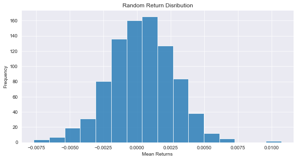

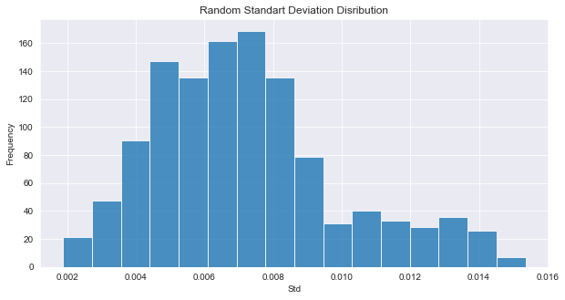

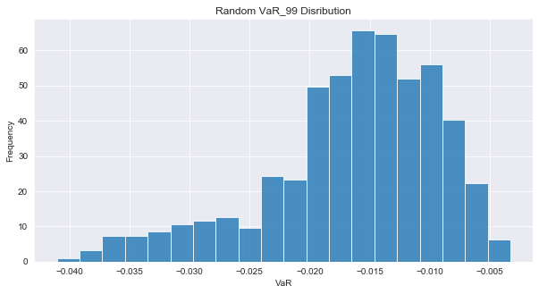

```python
plt.figure(figsize=(10,5))
plt.hist(spMean_rand,bins='rice',alpha=0.8,density = True)
plt.title('Random Return Disribution')
plt.xlabel('Mean Returns')
plt.ylabel('Frequency')
plt.show()
plt.figure(figsize=(10,5))
plt.hist(std_dev_rand,bins='rice',alpha=0.8,density = True)
plt.title('Random Standart Deviation Disribution')
plt.xlabel('Std')
plt.ylabel('Frequency')
plt.show()
# This last one takes a lot to load to keep in mind that it might take a while
plt.figure(figsize=(10,5))
plt.hist(VaR_99_random,bins=20,alpha=0.8,density = True)
plt.title('Random VaR_99 Disribution')
plt.xlabel('VaR')
plt.ylabel('Frequency')
plt.show()
```

*In the case of the distribution, we see that the VaR keeps being close to the original one. If we try even more simulations, it might be even more close.*

#### Question 11. If we suppose that price returns are iid Gaussian variables, determine, with the help of simulations, the distribution of the EVT parameters as well as the corresponding distribution of VaR.

\begin{align} \ VaR(p) = \frac{(\frac{k}{n(1-p)})^{\xi^{P}}-1}{1-2^{-\xi^{P}}}(X_{n-k+1:n} - X_{n-2k+1:n}) + X_{n-k+1:n} \end{align}

```
The average VaR is: -0.020263314442102796
```

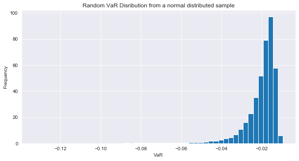

```python
pickPara_rand = []
VaRpickand_rand = []
k = 10

for i in range(10000):

    rand_ret = np.array(np.random.normal(sp500['Returns'].mean(), sp500['Returns'].std(), 300))
    rand_ret = random.sample(list(rand_ret),200)
    n = len(rand_ret)
    p = 0.99
    est_pickand = pickandsEstimator(rand_ret , k)
    xiP = (est_pickand)
    Var_Pick = pickandsVAR(p , xiP , k , rand_ret )

    pickPara_rand.append(est_pickand)
    VaRpickand_rand.append(Var_Pick)
print('The average VaR is: '+str(np.mean(VaRpickand_rand)))
plt.figure(figsize=(10,5))
plt.hist(VaRpickand_rand,bins=50,density=True)
plt.title('Random VaR Disribution from a normal distributed sample')
plt.xlabel('VaR')
plt.ylabel('Frequency')
plt.show()
```

#### Question 12. Apply the same method than the one exposed in Question 11 to determine the distribution of VaR in the fBm case.

Based on : SIMULATION AND IDENTIFICATION OF THE FRACTIONAL BROWNIAN MOTION: A BIBLIOGRAPHICAL AND COMPARATIVE STUDY

```
- by : COEURJOLLY Jean-François
- url : https://www.jstatsoft.org/article/view/v005i07/simest.pdf
- Reference : Peltier R.F., Processus stochastiques fractals avec  applications en finance, p.42, 28.12.1997
```

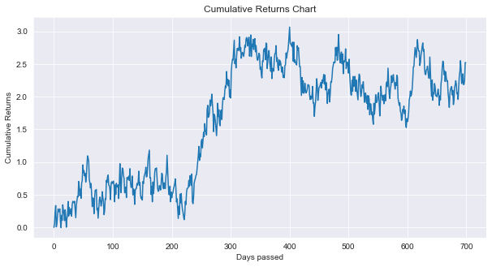

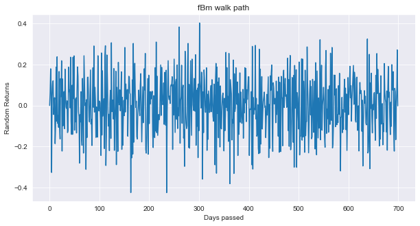

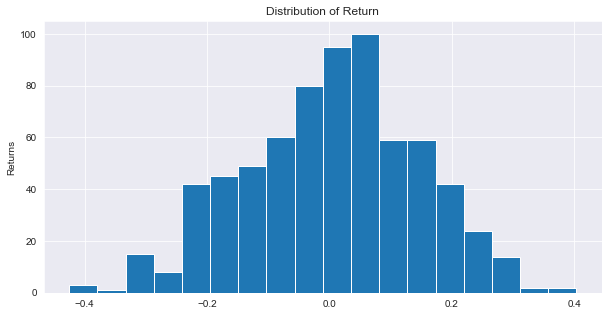

```python
def Levinson_fBm(n,H,graph):

    ## -------------------------------------------------------------------------
    ## Input :
    ## n ---- length of the desired sample
    ## H ---- self-similarity parameter
    ## graph = True ----- charts charts about the cumsum of the mouvements, plot and the histogram
    ##
    ## Output : simulation of a standard fractional Brownian motion
    ## at times { 0, 1/n,..., n-1/n }
    ## by  Levinson’s method’s decomposition of the covariance
    ## matrix of the fBm
    ##
    ## Example :  Levinson_fBm(n=500,H=0.6,True)
    ##
    ## --------------------------------------------------------------------------

    H2 = 2*H
    k = np.array(range(0,n))
    r = (abs((k - 1)/n)**H2 - 2 * (k/n)**H2 + ((k + 1)/n)**H2)/2 ##
    y = np.random.normal(size=n)
    fGn = np.zeros(n)
    v1 = r
    v2 = np.concatenate((0, r[1:n+1],0), axis=None)
    k = -v2[1]
    aa = np.sqrt(r[0]) ##
    for j in range(1,n):
        aa = aa *np.sqrt(1 - k * k)
        v = k*v2[j:n]+v1[(j-1):(n-1)]
        v2[j:n] = v2[j:n]+k*v1[j-1:n-1]
        v1[j:n] = v
        bb = y[j]/aa
        fGn[j:] = fGn[j:] + bb * v1[j:]
        #k = - v2[j + 1]/(aa * aa)
    cumsum_fBm  = np.cumsum(fGn)

    if graph == True:

        plt.figure(figsize=(10,5))
        plt.plot(fGn.cumsum())
        plt.title('Cumulative Returns Chart')
        plt.xlabel('Days passed')
        plt.ylabel('Cumulative Returns')
        plt.show()
        plt.figure(figsize=(10,5))
        plt.plot(fGn)
        plt.title('fBm walk path')
        plt.xlabel('Days passed')
        plt.ylabel('Random Returns')
        plt.show()
        plt.figure(figsize=(10,5))
        plt.title('Distribution of Return')
        plt.ylabel('Returns')
        plt.hist(fGn,bins='rice')
        plt.show()
        return fGn, cumsum_fBm

    else:

        return fGn, cumsum_fBm

rand_fBm, cumsum_fBm = Levinson_fBm(700,0.3,True)
```

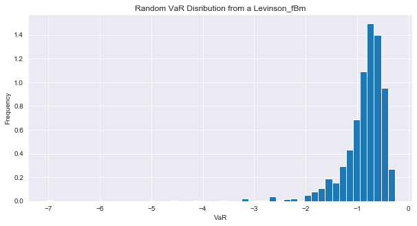

```python
pickPara_rand = []
VaRpickand_rand = []
k = 10

for i in range(1000):

    rand_fBm, cumsum_fBm = Levinson_fBm(300,0.4,False)
    rand_ret = random.sample(list(rand_fBm),200)
    rand_ret = sorted(rand_ret,reverse=False)
    n = len(rand_ret)
    p = 0.01
    est_pickand = (1/np.log(2))*np.log((rand_ret[n-k+1]-rand_ret[n-2*k+1])/
                                      (rand_ret[n-k+1]-rand_ret[n-4*k+1]))
    xiP = (est_pickand)


    Var_Pick = ((((((k/n*(1-p)))**xiP)-1)/(1-2**(-xiP)))*(rand_ret[n-k+1]-rand_ret[n-2*k+1])) + rand_ret[n-k+1]

    pickPara_rand.append(pickPara_rand)
    VaRpickand_rand.append(Var_Pick)

plt.figure(figsize=(10,5))
plt.hist(VaRpickand_rand,bins=50,density=True)
plt.title('Random VaR Disribution from a Levinson_fBm')
plt.xlabel('VaR')
plt.ylabel('Frequency')
plt.show()
```

#### Question 13. Represent in a graph the nonparametric VaR as a function of the bandwidth parameter of the kernel. Explain the method used to get this result.

Kernel density estimation is a really useful statistical tool that let’s you create a smooth curve given a set of data.This can be useful if you want to visualize just the “shape” of some data, as a kind of continuous replacement for the discrete histogram.

The KDE algorithm takes a parameter, bandwidth, that affects how “smooth” the resulting curve is. The KDE is calculated by weighting the distances of all the data points we’ve seen for each location on the line. If we’ve seen more points nearby, the estimate is higher, indicating that probability of seeing a point at that location.

Changing the bandwidth changes the shape of the kernel: a lower bandwidth means only points very close to the current position are given any weight, which leads to the estimate looking squiggly; a higher bandwidth means a shallow kernel where distant points can contribute.

The concept of weighting the distances of our observations from a particular point, $x$, can be expressed mathematically as follows:

$$ f(x) = \sum_{observations} K (\frac{x - observation}{bandwidth}) $$

```python
q13_mean = sp500['Returns'].mean()
q13_std =  sp500['Returns'].std()
var_non_para = []
confidence_level = 0.01
for i in range(10000):
    sim = 1000
    sim_returns = np.random.normal(q13_mean, q13_std, sim)
    var_np =  np.percentile(sim_returns, confidence_level)
    var_non_para.append(var_np)
```

```
We can see that the best bandwidth is difficult to choose since there will always be gapes between the aproximiation and the real chart bins.
```

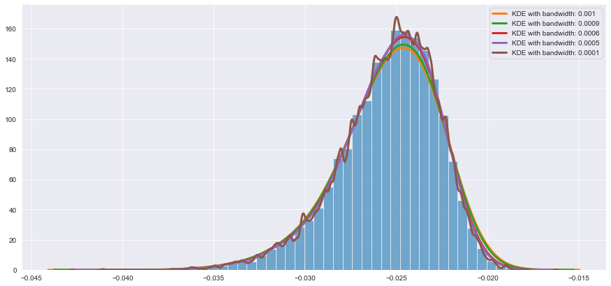

```python
fig = plt.figure(figsize=(15,7))
ax = fig.add_subplot(111)
ax.hist(var_non_para,bins='rice', density=True,alpha=0.6)
for i in [0.001,0.0009,0.0006,0.0005,0.0001]:
    KDE = sm.nonparametric.KDEUnivariate(var_non_para)
    KDE.fit(bw=i)
    ax.plot(KDE.support,KDE.density,linewidth=3,label = 'KDE with bandwidth: '+str(i))
ax.legend()
print('We can see that the best bandwidth is difficult to choose since there will always be gapes between the aproximiation and the real chart bins.')
```

### 4. Model risk as specification uncertainty

#### Question 14. Using the VaRs and ESs implemented in the first two sections, determine the diameter for VaRs as well as the diameter for ESs. Comment the result with respect to model risk: is it more relevant to use ES or VaR?

Remember this:

- np.quantile(a, 0.5) = 3.5
- np.percentile(a, 50) = 3.5

```python
sp500_array = np.array(sp500.Returns.copy())
```

```python
def VaR_all(p, xArray):
    """
    p should be 0.99, 0.95, 0.90
    To match with the pickand
    """
    p_b = 100 - p*100
    ######### Empirical VaR ###########
    xArray.sort()
    VaR_emp = np.percentile(xArray, p_b)
    ######### Parametric VaR ###########
    arr_mean = np.mean(xArray)
    arr_std = np.std(xArray)
    p_c = 1-p
    VaR__para = norm.ppf(p_c, arr_mean, arr_std)
    ######### Non Parametric VaR ###########
    sim_returns = []
    for i in range(10000):
        rand_rets = np.random.normal(arr_mean, arr_std)
        sim_returns.append(rand_rets)
    VaR__Npara = np.percentile(sim_returns, p_c)
    VaR__Npara = (VaR__Npara , np.mean(list(filter(lambda x : x <= VaR__Npara , sim_returns))))

    ######### Pickand VaR ###########
    pickPara = pickandsEstimator(xArray , 5)
    p = 0.99
    VaR_pickand = pickandsVAR(p , xi , 5 , xArray)

    return VaR_emp,VaR__para,VaR__Npara , VaR_pickand
```

```python
def VaR_CVaR_all(p, xArray):
    print('___________________________________________________________________________________________________')
    print('\nFor the following p: '+str(p))
    VaR_emp, VaR__para, VaR__Npara, VaR_pickand = VaR_all(p, xArray)

    CVaR_Hist = xArray[xArray <= VaR_emp].mean()
    CVaR_Para = xArray[xArray <= VaR__para].mean()
    CVaR_Npara = VaR__Npara[1]
    CVaR_Pick = xArray[xArray <= VaR_pickand].mean()

    print('\nWe have the following results:',
         '\n Empirical VaR: '+str(VaR_emp),
         '\n Parametric VaR: '+str(VaR__para),
         '\n Non-Parametric VaR: '+str(VaR__Npara[0]),
         '\n Pickands VaR: '+str(VaR_pickand),
         '\n Empirical CVaR: '+str(CVaR_Hist),
         '\n Parametric CVaR: '+str(CVaR_Para),
         '\n Non-Parametric CVaR: '+str(CVaR_Npara),
         '\n Pickands CVaR: '+str(CVaR_Pick))

    return VaR_emp, VaR__para, VaR__Npara, VaR_pickand, CVaR_Hist, CVaR_Para, CVaR_Npara, CVaR_Pick
```

```python
def get_Diameter(p, xArray):

    VaR_emp, VaR__para, VaR__Npara, VaR_pickand, CVaR_Hist, CVaR_Para, CVaR_Npara, CVaR_Pick = VaR_CVaR_all(p, xArray)

    list_VaR_str = ['VaR_emp', 'VaR__para', 'VaR__Npara', 'VaR_pickand']
    list_VaR = [VaR_emp, VaR__para, VaR__Npara[0], VaR_pickand]
    max_VaR = max(list_VaR)
    ind_VaRmax = list_VaR.index(max(list_VaR))
    max_VaRname = list_VaR_str[ind_VaRmax]
    min_VaR = min(list_VaR)
    ind_VaRmin = list_VaR.index(min(list_VaR))
    min_VaRname = list_VaR_str[ind_VaRmin]

    list_CVaR_str = ['CVaR_Hist', 'CVaR_Para', 'CVaR_Npara', 'CVaR_Pick']
    list_CVaR = [CVaR_Hist, CVaR_Para, CVaR_Npara, CVaR_Pick]
    max_CVaR = max(list_CVaR)
    ind_CVaRmax = list_CVaR.index(max(list_CVaR))
    max_CVaRname = list_CVaR_str[ind_CVaRmax]
    min_CVaR = min(list_CVaR)
    ind_CVaRmin = list_CVaR.index(min(list_CVaR))
    min_CVaRname = list_CVaR_str[ind_CVaRmin]

    print('\nMax VaR is the '+str(max_VaRname)+' with a value of : '+str(max_VaR))
    print('Min VaR is the '+str(min_VaRname)+' with a value of : '+str(min_VaR))
    print('Max CVaR is the '+str(max_CVaRname)+' with a value of : '+str(max_CVaR))
    print('Min CVaR is the '+str(min_CVaRname)+' with a value of : '+str(min_CVaR))

    print('\nThe diameter of the VaR is the difference of '+str(max_VaRname)+' and '+str(min_VaRname)+
          ' equals to '+str(abs(max_VaR-min_VaR)) )
    print('The diameter of the CVaR is the difference of '+str(max_CVaRname)+' and '+str(min_CVaRname)+
          ' equals to '+str(abs(max_CVaR-min_CVaR)) )

    if abs(max_VaR-min_VaR) > abs(max_CVaR-min_CVaR):
        print('\nChoosing the CVaR is better since the diameter of the min max is tigher.')
    else:
        print('\nChoosing the VaR is better since the diameter of the min max is tigher.')
```

```python
get_Diameter(0.99, sp500_array)
```

```
___________________________________________________________________________________________________

For the following p: 0.99

We have the following results:
 Empirical VaR: -0.02469498851801592
 Parametric VaR: -0.018297795990450255
 Non-Parametric VaR: -0.030588098014610834
 Pickands VaR: -0.027082561088108068
 Empirical CVaR: -0.03323851155909675
 Parametric CVaR: -0.026797159894242688
 Non-Parametric CVaR: -0.030771630172473686
 Pickands CVaR: -0.035879424925523117

Max VaR is the VaR__para with a value of : -0.018297795990450255
Min VaR is the VaR__Npara with a value of : -0.030588098014610834
Max CVaR is the CVaR_Para with a value of : -0.026797159894242688
Min CVaR is the CVaR_Pick with a value of : -0.035879424925523117

The diameter of the VaR is the difference of VaR__para and VaR__Npara equals to 0.01229030202416058
The diameter of the CVaR is the difference of CVaR_Para and CVaR_Pick equals to 0.009082265031280429

Choosing the CVaR is better since the diameter of the min max is tigher.
```

#### Question 15. Is your conclusion at Question 14 the same if you change the confidence level from 99% to 90%, 95%, 98%, 99.5%, 99.9%, and 99.99%?

*As we go towards extreme confidence levels, our estimation chooses even more the ES vs VaR. This is logic since the ES will be a better measure for extreme confidence level even thought the ES is more sensitive to the tail.*

```python
list_conf = [0.9, 0.95, 0.98,0.99, 0.995, 0.999, 0.9999]
for p in list_conf:
    get_Diameter(p, sp500_array)
```

```
___________________________________________________________________________________________________

For the following p: 0.9

We have the following results:
 Empirical VaR: -0.008346363933189448
 Parametric VaR: -0.009903561174047172
 Non-Parametric VaR: -0.02272533442379635
 Pickands VaR: -0.027082561088108068
 Empirical CVaR: -0.015373874574703763
 Parametric CVaR: -0.017173629040105
 Non-Parametric CVaR: -0.025977935942861036
 Pickands CVaR: -0.035879424925523117

Max VaR is the VaR_emp with a value of : -0.008346363933189448
Min VaR is the VaR_pickand with a value of : -0.027082561088108068
Max CVaR is the CVaR_Hist with a value of : -0.015373874574703763
Min CVaR is the CVaR_Pick with a value of : -0.035879424925523117

The diameter of the VaR is the difference of VaR_emp and VaR_pickand equals to 0.01873619715491862
The diameter of the CVaR is the difference of CVaR_Hist and CVaR_Pick equals to 0.020505550350819354

Choosing the VaR is better since the diameter of the min max is tigher.
___________________________________________________________________________________________________

For the following p: 0.95

We have the following results:
 Empirical VaR: -0.013094971219800825
 Parametric VaR: -0.012822448604958828
 Non-Parametric VaR: -0.026028923218632743
 Pickands VaR: -0.027082561088108068
 Empirical CVaR: -0.020270918947514614
 Parametric CVaR: -0.020270918947514614
 Non-Parametric CVaR: -0.028231850384658315
 Pickands CVaR: -0.035879424925523117

Max VaR is the VaR__para with a value of : -0.012822448604958828
Min VaR is the VaR_pickand with a value of : -0.027082561088108068
Max CVaR is the CVaR_Hist with a value of : -0.020270918947514614
```

[output cut: 106 more lines]

```
 Pickands VaR: -0.027082561088108068
 Empirical CVaR: -0.04097922501640716
 Parametric CVaR: -0.035879424925523117
 Non-Parametric CVaR: -0.03047649592458974
 Pickands CVaR: -0.035879424925523117

Max VaR is the VaR_pickand with a value of : -0.027082561088108068
Min VaR is the VaR_emp with a value of : -0.040860088030422806
Max CVaR is the CVaR_Npara with a value of : -0.03047649592458974
Min CVaR is the CVaR_Hist with a value of : -0.04097922501640716

The diameter of the VaR is the difference of VaR_pickand and VaR_emp equals to 0.013777526942314738
The diameter of the CVaR is the difference of CVaR_Npara and CVaR_Hist equals to 0.01050272909181742

Choosing the CVaR is better since the diameter of the min max is tigher.
```

#### Question 16. Add a noise process (say a Gaussian white noise) to the price return process and calculate the average impact on the VaR for each model. Which VaR method is the most robust? Display your results for various amplitudes of noise.

*Adding white noise it means that the mean will not change but only the standard deviation. The Non-Parametric VaR captures the best this time.*

```python
plusNoise = sp500.Returns.copy()
np.random.seed(0)
plusNoise = np.array(plusNoise.apply(lambda x : x + np.random.normal()))
np.random.seed()
get_Diameter(0.99, plusNoise)
```

```
___________________________________________________________________________________________________

For the following p: 0.99

We have the following results:
 Empirical VaR: -2.4458893280067033
 Parametric VaR: -2.402997320219152
 Non-Parametric VaR: -3.860288487432959
 Pickands VaR: -2.4852763478756295
 Empirical CVaR: -2.724128846952011
 Parametric CVaR: -2.724128846952011
 Non-Parametric CVaR: -3.9127642971014986
 Pickands CVaR: -2.724128846952011

Max VaR is the VaR__para with a value of : -2.402997320219152
Min VaR is the VaR__Npara with a value of : -3.860288487432959
Max CVaR is the CVaR_Hist with a value of : -2.724128846952011
Min CVaR is the CVaR_Npara with a value of : -3.9127642971014986

The diameter of the VaR is the difference of VaR__para and VaR__Npara equals to 1.457291167213807
The diameter of the CVaR is the difference of CVaR_Hist and CVaR_Npara equals to 1.1886354501494876

Choosing the CVaR is better since the diameter of the min max is tigher.
```

#### Question 17. Remove the noise of the price return process using the projection of your signal at one scale. Do this with scaling functions (also called father wavelet).

- V0 is the orthogonal space of the low frequency signal.
- W0 is the orthogonal space of the high frequency signal.
- We project V1 in V0 and W0 by an orthogonal decomposition using the Haar filter (1 vanishing moment).
- For Y[t], YV0 is a constant equal to the average of X[t] , X[t+1].
- For Y[t], YW0 is given by the Haar wavelet for X[t] , X[t+1], i.e (X[t] - X[t+1]) / 2.
- Now, YW0 holds the highest frequency of the sequence. We can iterate the process for YV0.
- For this question, we will drop the first Hi-Freq coefficients istead of applying thresholding.
- We will also try to implement the Daubechies wavelet (2 vanishing moments), to compare denoises.

```python
def haarWaveletDenoising( X ):
    def lowFreq(n , a): # We just need the father function
        return (a[n] + a[n-1]) / 2
    X = np.array(X)
    if X.shape[0] % 2 :
        X = np.append(X , 0)

    YV0 = []
    for n in range(1 , len(X) , 2): # The step alows to implement the pooling.
        YV0.append( lowFreq(n , X) )

    return YV0


def D4WaveletDenoising( X ):
    def D4lowFreq(n , a): # We just need the father function
        denom_inv = 1 / (4 * np.sqrt(2))
        h0 , h1 , h2 , h3 = (np.sqrt(3) + 1) * denom_inv , \
                            (np.sqrt(3) + 3) * denom_inv , \
                            (np.sqrt(3) - 3) * denom_inv , \
                            (np.sqrt(3) - 1) * denom_inv
        return h0*a[n] + a[n+1]*h1 + a[n+2]*h2 + a[n+3]*h3

    X = np.array(X)
    if X.shape[0] % 2 :
        N= X.shape[0]+1
        X = np.append(X , [0 , 0 , 0 , 0])
    else:
        N= X.shape[0]
        X = np.append(X , [0 , 0 , 0])
    YV0 = []
    for n in range(0 , N , 2): # The step alows to implement the pooling.
        YV0.append( D4lowFreq(n , X) )

    return YV0
```

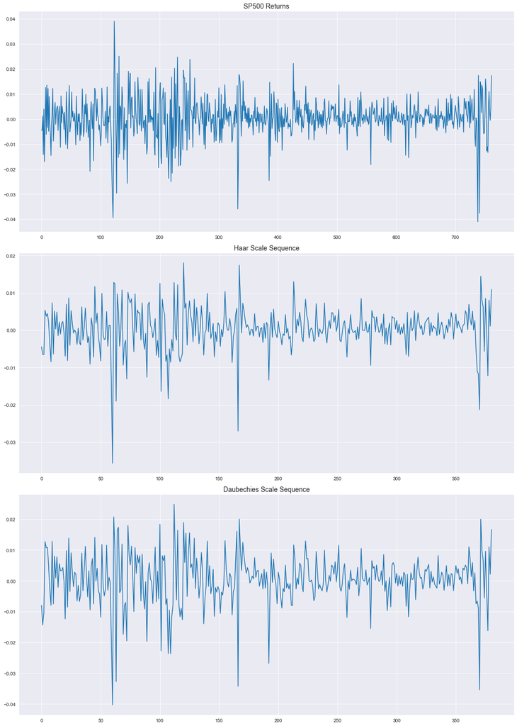

```python
fig, axarr = plt.subplots(nrows=3, ncols=1, figsize=(15,21))
axarr[0].set_title("SP500 Returns", fontsize=14)
axarr[0].plot(sp500.Returns.values)
axarr[1].set_title("Haar Scale Sequence", fontsize=14)
axarr[1].plot(haarWaveletDenoising(sp500.Returns.values))
axarr[2].set_title("Daubechies Scale Sequence", fontsize=14)
axarr[2].plot(D4WaveletDenoising(sp500.Returns.values))
plt.tight_layout()
plt.show()
```

#### Question 18. How do your VaR measures vary if they are applied to the denoised series? Display your results for various projection scales. Compare qualitatively your results with the ones of Question 16.

For this comparison we will use the data transformed with the Daubechies wavelet.

```python
spTrans = np.array(D4WaveletDenoising(sp500.Returns.values))
```

*Surprise, surprise, the CVaR is always chosen for every confidence level. Removing the noise helps to better use the CVaR since is sensitive to tail values.*

```python
list_conf = [0.9, 0.95, 0.98,0.99, 0.995, 0.999, 0.9999]
for p in list_conf:
    get_Diameter(p, spTrans)
```

```
___________________________________________________________________________________________________

For the following p: 0.9

We have the following results:
 Empirical VaR: -0.008075474391213965
 Parametric VaR: -0.010148146192036024
 Non-Parametric VaR: -0.024888454294541607
 Pickands VaR: -0.029316134703798236
 Empirical CVaR: -0.015652866234396844
 Parametric CVaR: -0.018617291360631998
 Non-Parametric CVaR: -0.02587212239488948
 Pickands CVaR: -0.035660442572626586

Max VaR is the VaR_emp with a value of : -0.008075474391213965
Min VaR is the VaR_pickand with a value of : -0.029316134703798236
Max CVaR is the CVaR_Hist with a value of : -0.015652866234396844
Min CVaR is the CVaR_Pick with a value of : -0.035660442572626586

The diameter of the VaR is the difference of VaR_emp and VaR_pickand equals to 0.021240660312584272
The diameter of the CVaR is the difference of CVaR_Hist and CVaR_Pick equals to 0.020007576338229742

Choosing the CVaR is better since the diameter of the min max is tigher.
___________________________________________________________________________________________________

For the following p: 0.95

We have the following results:
 Empirical VaR: -0.011829363314877068
 Parametric VaR: -0.013164504110918174
 Non-Parametric VaR: -0.02508738050436981
 Pickands VaR: -0.029316134703798236
 Empirical CVaR: -0.021214806804938813
 Parametric CVaR: -0.023474360180619044
 Non-Parametric CVaR: -0.027067282268457383
 Pickands CVaR: -0.035660442572626586

Max VaR is the VaR_emp with a value of : -0.011829363314877068
Min VaR is the VaR_pickand with a value of : -0.029316134703798236
Max CVaR is the CVaR_Hist with a value of : -0.021214806804938813
```

[output cut: 106 more lines]

```
 Pickands VaR: -0.029316134703798236
 Empirical CVaR: -0.0402708064129419
 Parametric CVaR: -0.035660442572626586
 Non-Parametric CVaR: -0.03332272411472901
 Pickands CVaR: -0.035660442572626586

Max VaR is the VaR_pickand with a value of : -0.029316134703798236
Min VaR is the VaR_emp with a value of : -0.040084293131806406
Max CVaR is the CVaR_Npara with a value of : -0.03332272411472901
Min CVaR is the CVaR_Hist with a value of : -0.0402708064129419

The diameter of the VaR is the difference of VaR_pickand and VaR_emp equals to 0.01076815842800817
The diameter of the CVaR is the difference of CVaR_Npara and CVaR_Hist equals to 0.006948082298212893

Choosing the CVaR is better since the diameter of the min max is tigher.
```